**Distribución normal:**  
práctica en `R`

Marta Coronado Zamora Octubre 2025

# La distribución normal

Muchos tests estadísticos asumen que la variable que se analiza sigue una **distribución normal**. Afortunadamente, muchos de estos tests son bastante robustos frente a esta suposición, es decir, funcionan razonablemente bien incluso cuando esta suposición no se cumple exactamente, especialmente cuando el tamaño de la muestra es grande. Por lo tanto, a menudo es suficiente poder evaluar si los datos provienen de una distribución cuya forma sea aproximadamente normal. Una manera de evaluarlo es a través de la visualizaciones.

**Tabla resumen de las principales funciones de la normal en `R`**

| Función | Qué hace |
| --- | --- |
| `rnorm(n, mean = 0, sd = 1)` | Genera *n* números aleatorios que siguen una distribución normal con una media y desviación estándar dadas. |
| `pnorm(q, mean = 0, sd = 1, lower.tail = TRUE)` | Calcula *P(X ≤ x)* para una media y desviación estándar dadas. Calcula *P(X > x)* cuando `lower.tail = FALSE`. |
| `qnorm(p, mean = 0, sd = 1, lower.tail = TRUE)` | Devuelve los valores críticos (cuantiles) de la distribución normal para un percentil, una media y una desviación estándar dadas. |

## 1. Visualización de normalidad con QQ-plots

Una tipo de gráfico que puede ayudarnos a visualizar si una variable es aproximadamente normal es el *quantile plot* (o **QQ-plot**). El QQ-plot muestra nuestros datos en el eje vertical (`y`) ordenados de menor a mayor (“**quantiles de la muestra**”), y en el eje horizontal (`x`) muestra el valor esperado con el mismo cuantil si la distribución fuera normal (“**quantiles teóricos**”). Si los datos provienen de una distribución normal, el QQ-plot debería seguir más o menos una **línea recta** (con cierta tolerancia por variación muestral).

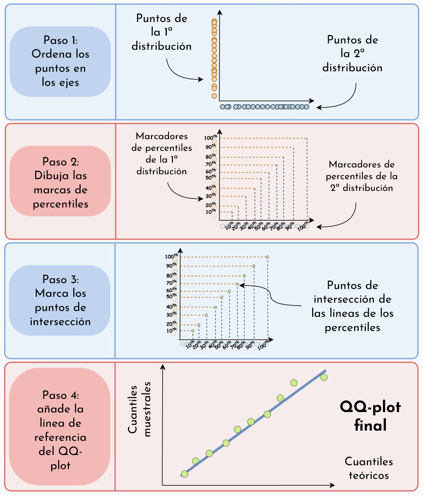

**Ejemplo: ¿sigue la edad de los pasarejos del Titanic una distribución normal?**

```r
library(ggplot2)

# leemos un dataframe con informacion de los pasarejos del Titanic
url <- "https://raw.githubusercontent.com/marta-coronado/biostatistics-uab/refs/heads/main/P/3/titanic.csv"
titanicData <- read.csv(url)

# vemos las primeras filas
head(titanicData)
```

```
##   passenger_class                                      name     age    embarked
## 1             1st                 Allen,MissElisabethWalton 29.0000 Southampton
## 2             1st                  Allison,MissHelenLoraine  2.0000 Southampton
## 3             1st           Allison,MrHudsonJoshuaCreighton 30.0000 Southampton
## 4             1st Allison,MrsHudsonJ.C.(BessieWaldoDaniels) 25.0000 Southampton
## 5             1st                Allison,MasterHudsonTrevor  0.9167 Southampton
## 6             1st                          Anderson,MrHarry 47.0000 Southampton
##              home_destination    sex survive
## 1                  StLouis,MO female     yes
## 2 Montreal,PQ/Chesterville,ON female      no
## 3 Montreal,PQ/Chesterville,ON   male      no
## 4 Montreal,PQ/Chesterville,ON female      no
## 5 Montreal,PQ/Chesterville,ON   male     yes
## 6                  NewYork,NY   male     yes
```

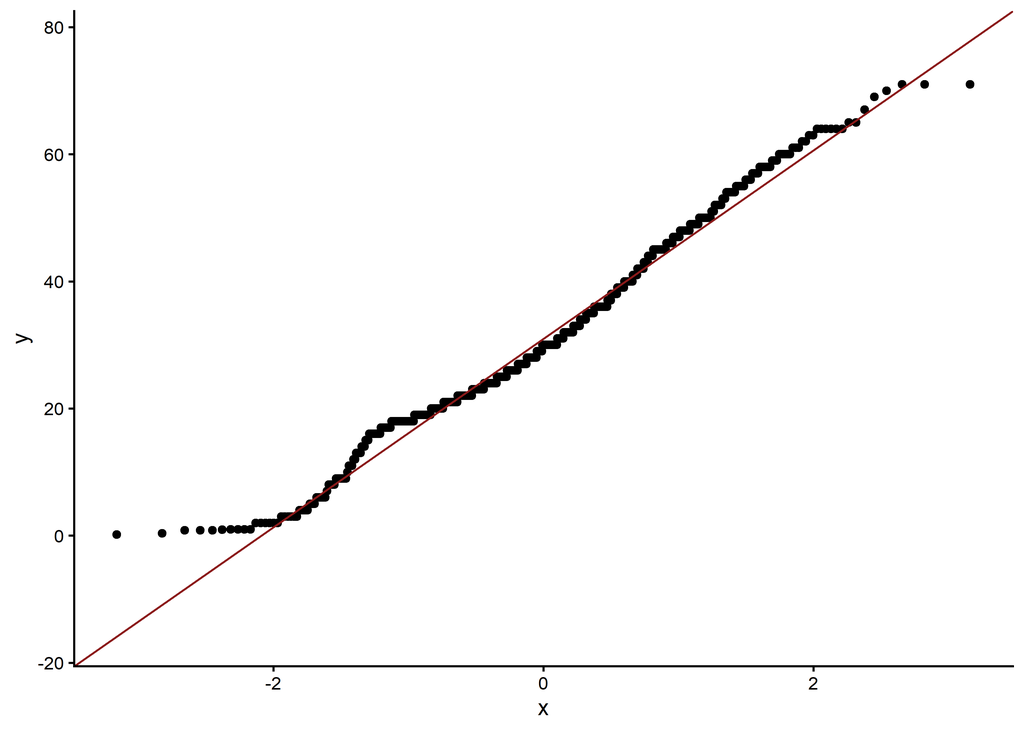

```r
# QQ-plot con ggplot2
ggplot(titanicData, aes(sample = age)) +
  stat_qq() + # cuantiles
  stat_qq_line(color = "firebrick4") + # línea de referencia
  theme_classic()
```

Es difícil interpretar los QQ-plots sin experiencia. Uno de los objetivos de los ejercicios de hoy será **desarrollar cierta experiencia visual** sobre cómo se ven estos gráficos cuando los datos son realmente normales.  
Para ello, aprovecharemos una función incorporada en R que genera **números aleatorios extraídos de una distribución normal**. Esta función se llama `rnorm()`.

## 2. La función `rnorm` para generar una distribución normal aleatoria

La función `rnorm()` devuelve un vector de números, todos generados aleatoriamente a partir de una distribución normal, con una media $\mu$ y una desviación estándard $s$. Recibe tres argumentos principales:

`rnorm(n, mean, sd)`

- `n`: cuántos números aleatorios generar
- `mean`: la media de la distribución normal de la que se extraen los datos
- `sd`: la desviación estándar de la distribución normal

**Prueba la función: genera un vector de 100 números aleatorios extraídos de una distribución normal con media 13 y desviación estándar 4.**

Vamos a visualizar el QQ-plot de los datos anteriores. Para ello, en vez de reciclar el código anterior, vamos a utilizar algo **nuevo** en `R`: **funciones propias**.

El siguiente bloque de código genera una nueva función en `R` que llamaremos “`QQ_plot()`”, que tomara como argumento un **vector numéricos de datos**.

**Ejecuta el siguiente bloque de código.**

```r
# Función para crear QQ-plot con ggplot2
QQ_plot <- function(vector_datos) {
  # Crear data frame con el vector numerico pasado como argumento
  df <- data.frame(valor = vector_datos)

  # QQ-plot con ggplot2
  ggplot(df, aes(sample = valor)) +
    stat_qq() +
    stat_qq_line(color = "firebrick4") +
    theme_classic() +
    labs(
      title = "QQ-plot",
      x = "Quantiles teóricos",
      y = "Quantiles de la muestra"
    )
}
```

**Vamos a probar si funciona:**

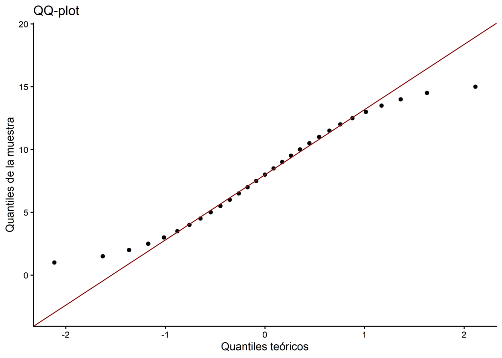

```r
# Vector numerico con valores de 1 al 15 cogidos de 0.5 en 0.5
nums <- seq(1,15,0.5)

# Ejecutamos nuestra función
QQ_plot(nums)
```

**Genera el QQ-plot para visualizar los 100 valores que has simulado antes.**

Estos puntos caen principalmente a lo largo de una línea recta, pero hay cierto **desvío alrededor de esa línea**, incluso cuando estos puntos sabemos que han sido realmente extraídos aleatoriamente de una distribución normal conocida. Por lo tanto, en un QQ-plot, buscamos un **patrón general que sea aproximadamente una línea recta**, pero no esperamos que sea perfecta.

## 3. Visualizar distribuciones con histogramas

Otro gráfico muy utilizado para visualizar una distribución y saber si sigue una distribución normal son los **histogramas**, que ya has trabajado en la P2.

**(Opcional) Genera un histograma con `geom_histogram()`**

```r
# Recuerda que tendrás que generar un dataframe primero

# tu_df <- data.frame(nombre_columna = vector_numeros)
```

## 4. Propiedades de la distribucion normal

En estadística, normalmente **no trabajamos con toda la población**, sino con **muestras** que extraemos de ella para hacer inferencias.`R` tiene una función, `sample()`, que permite **tomar una muestra aleatoria** de X de observaciones (`size`) a partir de un vector (`x`). La sintaxis es: `sample(x, size)`.

**1. Muestrea 10 observaciones de la siguiente poblacion simulada.**

```r
poblacion <- rnorm(1000, mean = 6, sd = 1)
```

**2. Calcula la media de la muestra con `mean()`.**

**3. Repite los pasos 1-2 1000 veces 😈**

¿A mano? ¡No! vamos a generar una nueva función en R.

La función `muestreo_vs_poblacion()` hará los pasos 1-3 por nosotros, ajustándose a cualquier población que queramos simular y al muestreo que queramos. La función hace:

- **Genera una población simulada** (`poblacion`) a partir de una distribución normal con una media (`media_pob`) y desviación estándar (`sd_pob`) especificadas.
- **Extrae varias muestras aleatorias** de esa población (según el parámetro `n_muestras`), cada una con un tamaño determinado (`tam_muestra`).
- **Calcula la media de cada muestra**, obteniendo así una distribución de medias muestrales.
- **Representa dos histogramas**:
  1. La **distribución original de la población**.
  2. La **distribución de las medias muestrales** obtenidas.

Ambos gráficos se muestran con el **mismo rango en el eje x** para que se pueda comparar visualmente.

**Ejecuta el siguiente código para cargar la nueva función.**

```r
library(ggplot2)
library(gridExtra)

# la función recoge como argumentos el numero de muestras que muestreamos, el tamaño de la muestra, la mediay la desviacion estándard poblacional y el tamaño de la población
muestreo_vs_poblacion <- function(n_muestras = 100, tam_muestra = 30, media_pob = 50, sd_pob = 10, tam_pob = 1000) {

  # Simular población normal
  set.seed(123)
  poblacion <- rnorm(tam_pob, mean = media_pob, sd = sd_pob)

  # Calcular medias muestrales: calcula la media de una muestra, dado un tamaño de muestra, tantas veces como queramos
  sample_means <- replicate(n_muestras, mean(sample(poblacion, tam_muestra)))

  # Creamos los data frames para ggplot
  df_pob <- data.frame(valor = poblacion)
  df_means <- data.frame(media = sample_means)

  # Determinar rango común para eje x
  rango_x <- range(c(df_pob$valor, df_means$media))

  # Histograma población
  g1 <- ggplot(df_pob, aes(x = valor)) +
    geom_histogram(binwidth = sd_pob/10, fill = "salmon2", color = "black") +
    xlim(rango_x) +
    theme_classic() +
    labs(
      title = paste0("Población completa de ", tam_pob ," observaciones - N(",media_pob,", ",sd_pob,")"),
      x = "Valor",
      y = "Frecuencia"
    )

  # Histograma medias muestrales
  g2 <- ggplot(df_means, aes(x = media)) +
    geom_histogram(binwidth = sd_pob/10, fill = "cadetblue4", color = "black") +
    xlim(rango_x) +
    theme_classic() +
    labs(
      title = paste0("Medias muestrales (núm. muestras = ", n_muestras, ", tamaño muestra = ", tam_muestra,"),\nN(",round(mean(df_means$media),3),", ",round(sd(df_means$media),3),")"),
      x = "Media de la muestra",
      y = "Frecuencia"
    )

  # Mostrar ambos gráficos
  grid.arrange(g1, g2, ncol = 1)
}
```

**Prueba la función:**

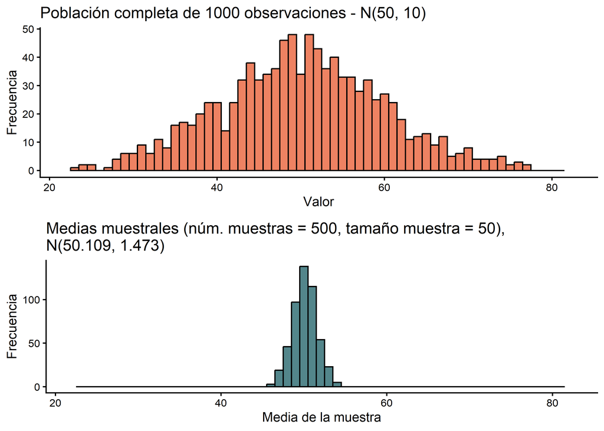

```r
# Ejemplo de uso
muestreo_vs_poblacion(n_muestras = 500, tam_muestra = 50, media_pob = 50, sd_pob = 10, tam_pob = 1000)
```

**Haz pruebas con la función para responder si las siguientes afirmaciones son verdaderas o falsas.**

- *La media de las medias muestrales se aproxima a la media poblacional.*
- *La distribución de las medias muestrales siempre tiene la misma desviación estándar que la población.*
- *Duplicar el tamaño de la muestra reduce a la mitad la desviación estándar de las medias muestrales.*
- *El número de veces que muestreamos afecta la forma de la distribución de medias muestrales.*

## 5. Ejemplo práctico con datos reales

Vamos a trabajar con la tabla “`mammals.csv`”, disponible en [este enlace](https://raw.githubusercontent.com/marta-coronado/biostatistics-uab/refs/heads/main/P/3/mammals.csv).

Lee y guarda en un objeto llamado `mammals` la tabla `mammals.csv` del siguiente enlace (usa el ejemplo del Titanic de más arriba):

```r
url <- "https://raw.githubusercontent.com/marta-coronado/biostatistics-uab/refs/heads/main/P/3/mammals.csv"
```

El archivo `mammals.csv` contiene información sobre la **masa corporal** de diversas especies de mamíferos.

**Representa la distribución de la masa corporal (columna `body_mass_kg`) utilizando un QQ-plot (recuerda usar tu función `QQ_plot()`). Describe la forma de la distribución. ¿Te parece que sigue una distribución normal?**

Una manera de acercar los datos a una distribución normal es utilizar una **escala logarítmica**. Con una transformación, aplicamos la misma **función matemática** a cada valor de una variable numérica del conjunto de datos. En el caso de la **transformación logarítmica**, tomamos el **logaritmo** de cada valor individual de la variable numérica.

Para ello, podemos crear una **nueva columna** que sea el logaritmo de la columna `body_mass_kg`.

En R, aplicar la transformación logarítmica es muy sencillo. En este caso, lo que haremos será **crear una nueva columna** dentro del mismo *dataframe* que contenga el valor transformado (en escala logarítmica). Así, conservamos la columna original y añadimos una nueva con la transformación.

```r
# Ejemplo
df$nuevo_valor_transformado <- log(df$valor_sin_transformar)
```

**Crea una nueva columna con el resultado de la transformación logarítmica de la columna `body_mass_kg`. Comprueba qué pasa ahora en el QQ-plot: ¿siguen los datos una distribución normal ahora?**

**Calcula la media y la desviación estándard de la columna con el logaritmo de `body_mass_kg`.**

## 6. La función `pnorm()`: probabilidad acumulada

La función `pnorm()` calcula la **probabilidad acumulada** de una distribución normal.  
Es decir, nos da la **probabilidad de que una variable aleatoria normal tome un valor menor (o mayor) o igual que un determinado número**.

Podemos usar `pnorm()` para calcular la **probabilidad de que un animal tenga una masa inferior (o superior) a X kg**.

**¿Cuál es la probabilidad de un animal con una masa inferior a 10kg?**

Considera la media y al desviación estándard que has calculado antes, es decir, con al transformación logarítmica. Recuerda transformar el 10 a escala logarítmica.

```r
# log(10)
```

## 7. La función `qnorm()`: obtener valores (cuantiles) a partir de probabilidades acumuladas

Vamos a ver la última función de la práctica, `qnorm()`. La función `qnorm()` nos devuelve el **valor crítico** (o cuantil) de una distribución normal para un determinado **percentil** o **nivel de probabilidad**. En otras palabras, nos dice el valor de *x* tal que la probabilidad acumulada hasta ese punto sea igual a *p*.

Por ejemplo:

```r
qnorm(0.5, mean = mean(log(mammals$body_mass_kg)), sd = sd(log(mammals$body_mass_kg)))
```

Devuelve el valor en escala logarítmica que representa el percentil 50 (la mediana) de la distribución del peso de los mamíferos.

Si queremos obtener este valor en kilogramos, debemos aplicar la función `exp()` para transformar el valor en escala logarítmica a normal:

```r
# Ejemplo
valor <- log(10)

exp(valor)
```

```
## [1] 10
```

**¿Cuál es el peso que separa al 1% de los animales más pesados del resto (percentil 99)?**

Recuerda transformar el valor a kg.

**Utiliza la función `filter()` para ver si en la tabla `mammals` hay algun animal con un peso superior al que acabas de obtener** (ejemplo en [esta diapositiva](https://marta-coronado.github.io/biostatistics-uab/T/2/2.IntroR.html#25)):

(OPCIONAL) **Encuentra qué animales están en el 5% de la cola inferior (los más pequeños).**